# Deep neural networks with tensorflow

### Introduction of topic

2-layer neural network for classification takes the following form, \begin{aligned} h_{1} &=\operatorname{ReLU}\left(W_{1} X+b_{1}\right) \\ p &=\operatorname{Softmax}\left(W_{2} h_{1}+b_{2}\right). \end{aligned} where $X$ is the input. The number of layers is referred to as the "depth" of a neural network. We can construct neural networks with arbitrary depth via the following architecture, \begin{aligned} h_{1} &=\operatorname{ReLU}\left(W_{1} X+b_{1}\right) \\ h_{2} &=\operatorname{ReLU}\left(W_{2} h_1 + b_{2}\right) \\ h_{3} &=\operatorname{ReLU}\left(W_{3} h_2 + b_{3}\right) \\ &\vdots\\ p &=\operatorname{Softmax}\left(W_{\ell} h_{\ell-1}+b_{\ell}\right). \end{aligned} This is an $\ell$-layer neural network. The $i$-th layer takes the output of the previous layer, $h_{i-1}$ as input, and produces $h_i$. The parameters of the $i$-th layer are the weights matrix $W_i$ and the bias vector $b_i$. The nonlinear activation function is $\operatorname{ReLU}$ at each hidden layer, and $\operatorname{Softmax}$ at the output layer.

```python
import numpy as np
import matplotlib.pyplot as plt
from tqdm import tqdm
import tensorflow as tf
from tqdm.keras import TqdmCallback

%matplotlib inline
plt.rcParams['figure.figsize'] = (10.0, 8.0)  # set default size of plots
plt.rcParams['image.interpolation'] = 'nearest'
plt.rcParams['image.cmap'] = 'gray'
# plt.rcParams['axes.facecolor'] = 'lightgray'
```

```python
def generate_spirals(N=100, K=3, noise=0.3):
    D = 2  # dimensionality
    X = np.zeros((N*K, D))
    y = np.zeros(N*K, dtype='uint8')
    for j in range(K):
        ix = range(N*j, N*(j+1))
        r = np.linspace(0.0, 1, N)  # radius
        t = np.linspace(j*4, (j+1)*4, N) + np.random.randn(N)*noise
        X[ix] = np.c_[r*np.sin(t), r*np.cos(t)]
        y[ix] = j
    return X, y

def plot_data(X, y):
    fig = plt.figure()
    plt.scatter(X[:, 0], X[:, 1], c=y, s=40, cmap=plt.cm.Spectral)
    plt.xlim(np.min(X[:,0])-.1, np.max(X[:,0])+.1)
    plt.ylim(np.min(X[:,1])-.1, np.max(X[:,1])+.1)


def plot_classifier(X, y, model):
    h = 0.015
    x_min, x_max = X[:, 0].min() - .2, X[:, 0].max() + .2
    y_min, y_max = X[:, 1].min() - .2, X[:, 1].max() + .2
    xx, yy = np.meshgrid(np.arange(x_min, x_max, h),
                         np.arange(y_min, y_max, h))
    # Z = np.dot(np.maximum(
    #     0, np.dot(np.c_[xx.ravel(), yy.ravel()], W1) + b1), W2) + b2
    inputs = np.array([xx.ravel(), yy.ravel()]).T
    Z = model(inputs)
    Z = np.argmax(Z, axis=1)
    Z = Z.reshape(xx.shape)
    fig = plt.figure()
    plt.contourf(xx, yy, Z, cmap=plt.cm.Spectral, alpha=0.5)
    plt.scatter(X[:, 0], X[:, 1], c=y, s=40, cmap=plt.cm.Spectral)
    plt.xlim(xx.min(), xx.max())
    plt.ylim(yy.min(), yy.max())

def plot_history(history, val=False, figsize=(8,3)):
    '''plot given attributes from training history'''
    plot_attrs = ('loss', 'accuracy')
    fig, axs = plt.subplots(ncols=len(plot_attrs), figsize=figsize)

    if not all(plot_attr in history.history for plot_attr in plot_attrs):
        raise ValueError('not all `plot_attrs` are in the history object')

    for plot_attr, ax in zip(plot_attrs, axs):
        ax.plot(history.history[plot_attr], label=plot_attr)
        if val:
            ax.plot(history.history[f'val_{plot_attr}'], label=f'val_{plot_attr}')
        ax.set_ylabel(plot_attr)
        ax.set_xlabel('epoch')
        ax.legend(loc='upper right')

    return fig

def train_neurnet(neurnet, X, y, X_val, y_val, n_epochs=1_000, batch_size=128):
    neurnet.compile(loss='sparse_categorical_crossentropy', optimizer='sgd', metrics=['accuracy'])
    history = neurnet.fit(
        X, y, validation_data=(X_val, y_val), epochs=n_epochs, batch_size=batch_size, verbose=0,
        callbacks=[TqdmCallback(data_size = len(y), batch_size=batch_size, verbose=0)])
    plot_history(history, val=True);
    return history
```

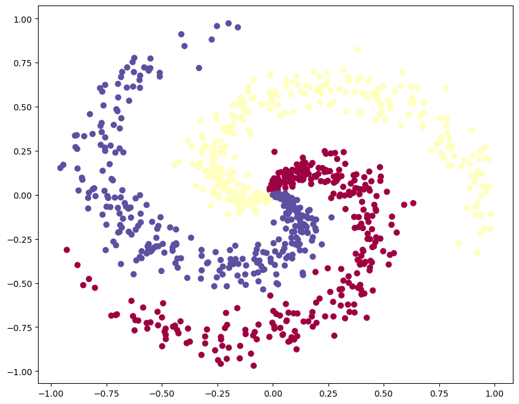

```python
X_spiral, y_spiral = generate_spirals(N=300, K=3)
X_spiral_val, y_spiral_val = generate_spirals(N=50, K=3)
X_spiral_test, y_spiral_test = generate_spirals(N=300, K=3)
plot_data(X_spiral, y_spiral)
```

Now, let's train a 2-layer neural network to classify this dataset.

```python
neurnet = tf.keras.Sequential(
    [
        tf.keras.layers.Dense(units=64, activation='relu'),
        tf.keras.layers.Dense(units=3, activation='softmax')
    ])

neurnet.build(input_shape=(None, 2))
neurnet.summary()
```

```
Model: "sequential"
```

```
┏━━━━━━━━━━━━━━━━━━━━━━━━━━━━━━━━━┳━━━━━━━━━━━━━━━━━━━━━━━━┳━━━━━━━━━━━━━━━┓
┃ Layer (type)                    ┃ Output Shape           ┃       Param # ┃
┡━━━━━━━━━━━━━━━━━━━━━━━━━━━━━━━━━╇━━━━━━━━━━━━━━━━━━━━━━━━╇━━━━━━━━━━━━━━━┩
│ dense (Dense)                   │ (None, 64)             │           192 │
├─────────────────────────────────┼────────────────────────┼───────────────┤
│ dense_1 (Dense)                 │ (None, 3)              │           195 │
└─────────────────────────────────┴────────────────────────┴───────────────┘
```

```
 Total params: 387 (1.51 KB)
```

```
 Trainable params: 387 (1.51 KB)
```

```
 Non-trainable params: 0 (0.00 B)
```

```
0epoch [00:00, ?epoch/s]
```

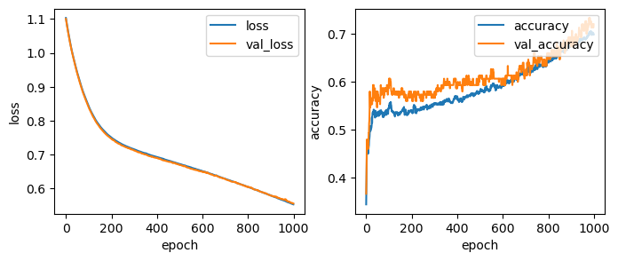

```python
history = train_neurnet(neurnet, X_spiral, y_spiral, X_spiral_val, y_spiral_val, n_epochs=1_000)
```

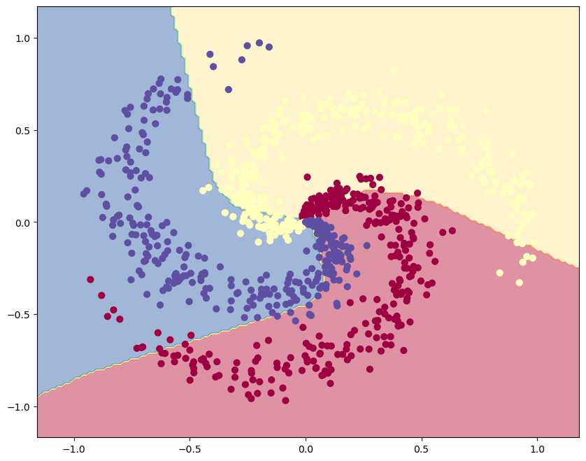

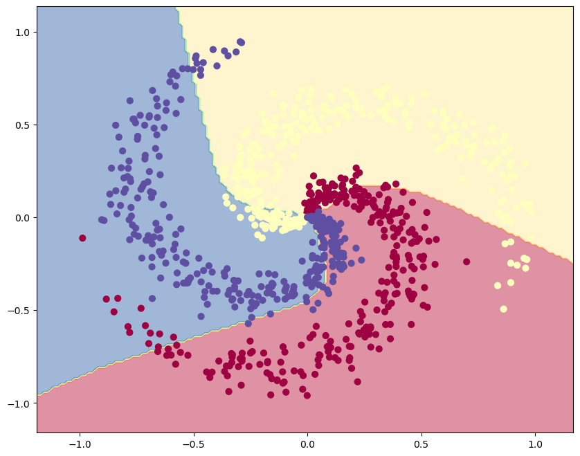

```python
plot_classifier(X_spiral, y_spiral, neurnet)
plot_classifier(X_spiral_test, y_spiral_test, neurnet)
```

### Experiment with different architectures and hyperparameters settings

```
0epoch [00:00, ?epoch/s]
```

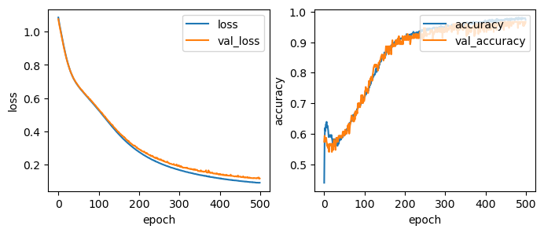

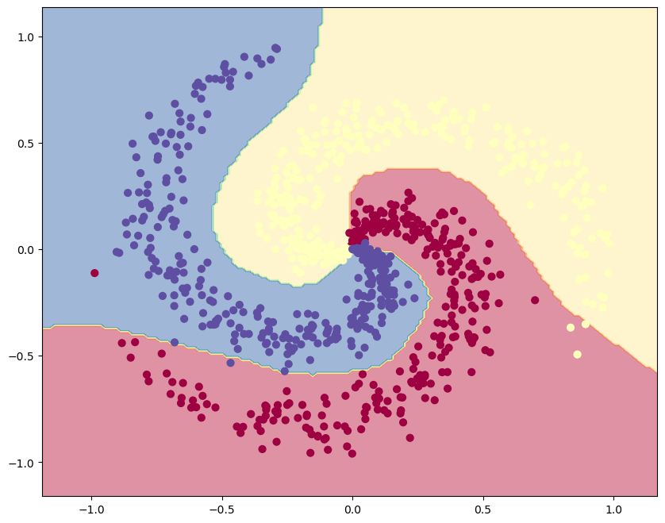

```python
from tensorflow.keras import Sequential
from tensorflow.keras.layers import Dense
wider_neurnet = Sequential([
    Dense(128, activation='relu', input_shape=(2,)),  # Wider hidden layer
    Dense(128, activation='relu'),  # Second wider hidden layer
    Dense(3, activation='softmax')  # Output layer
])

# Train the wider network
history_wider = train_neurnet(
    wider_neurnet,
    X_spiral, y_spiral,
    X_spiral_val, y_spiral_val,
    n_epochs=500, batch_size=32
)

# Visualize the decision boundaries
plot_classifier(X_spiral_test, y_spiral_test, wider_neurnet)
```

### Deeper network

```
0epoch [00:00, ?epoch/s]
```

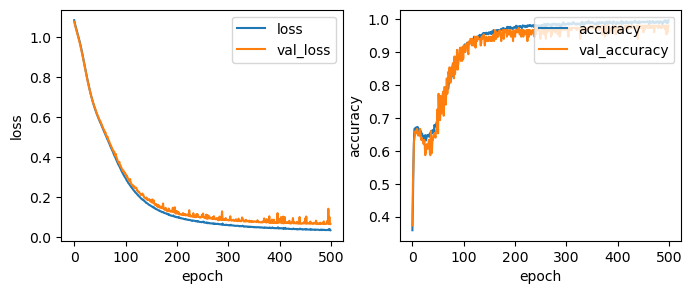

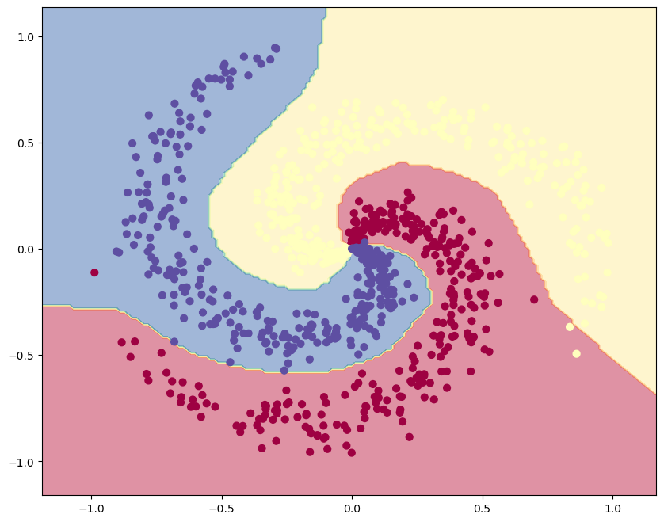

```python
deeper_neurnet = Sequential([
    Dense(64, activation='relu', input_shape=(2,)),  # First hidden layer
    Dense(64, activation='relu'),  # Second hidden layer
    Dense(64, activation='relu'),  # Additional hidden layer
    Dense(3, activation='softmax')  # Output layer
])

# Train the deeper network
history_deeper = train_neurnet(
    deeper_neurnet,
    X_spiral, y_spiral,
    X_spiral_val, y_spiral_val,
    n_epochs=500, batch_size=32
)

# Visualize the decision boundaries
plot_classifier(X_spiral_test, y_spiral_test, deeper_neurnet)
```

### Classification with "circle"

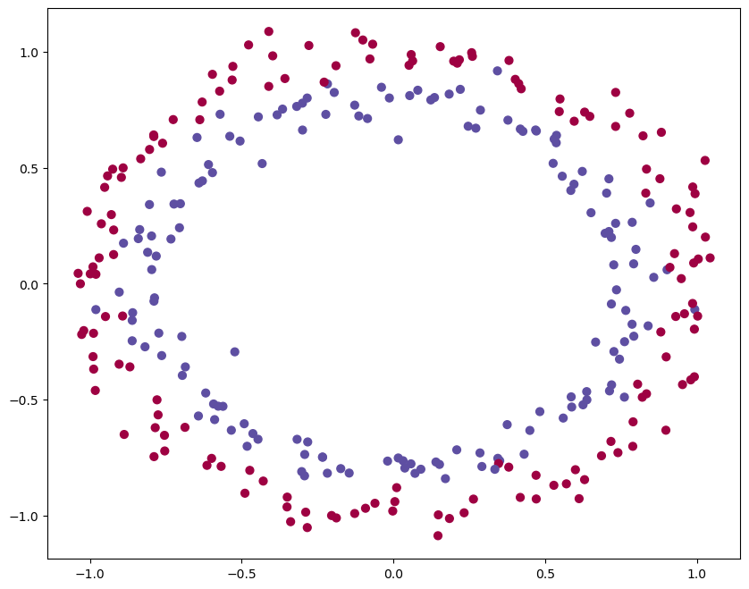

```python
from sklearn import datasets

# generate circles
X_circles, y_circles = datasets.make_circles(300, noise=0.06, random_state=265)
X_circles_val, y_circles_val = datasets.make_circles(100, noise=0.06, random_state=565)
X_circles_test, y_circles_test = datasets.make_circles(300, noise=0.06, random_state=565)

plot_data(X_circles, y_circles)
```

```
0epoch [00:00, ?epoch/s]
```

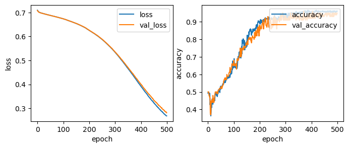

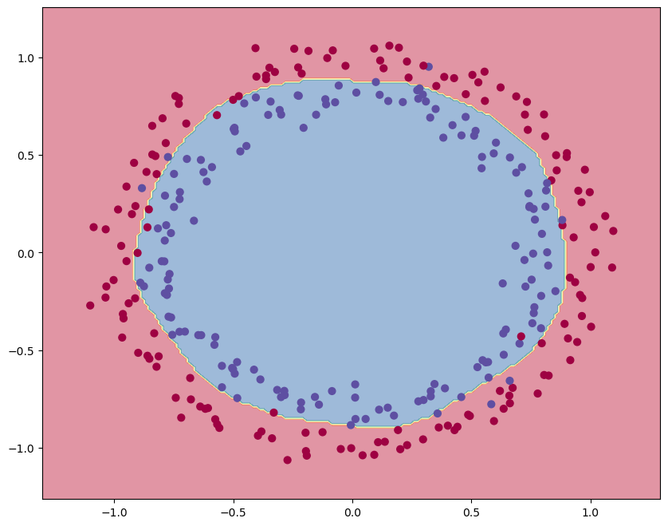

```python
from tensorflow.keras import Sequential
from tensorflow.keras.layers import Dense
from tensorflow.keras.optimizers import SGD

circles_neurnet = Sequential([
    Dense(64, activation='relu', input_shape=(2,)),
    Dense(64, activation='relu'),
    Dense(2, activation='softmax')
])

history_circles = train_neurnet(
    circles_neurnet,
    X_circles, y_circles,
    X_circles_val, y_circles_val,
    n_epochs=500, batch_size=32
)

plot_classifier(X_circles_test, y_circles_test, circles_neurnet)
```

### classification with "Blobs"

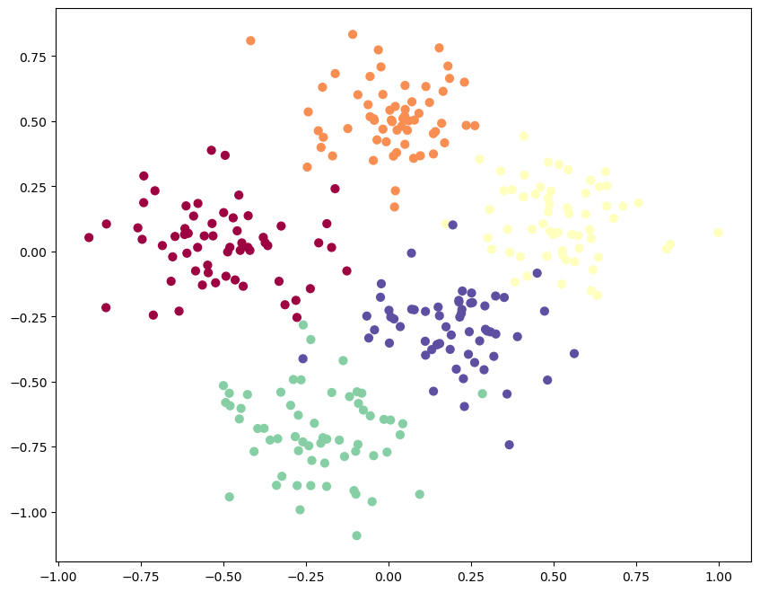

```python
centers = np.array([[-.5,.0],[0,.5], [.5,.1], [-.2, -.7], [.2, -.3]])
X_blobs, y_blobs = datasets.make_blobs(300, centers=centers, cluster_std=.15, center_box=(-1.0, 1.0), random_state=265)
X_blobs_val, y_blobs_val = datasets.make_blobs(100, centers=centers, cluster_std=.15, center_box=(-1.0, 1.0), random_state=565)
X_blobs_test, y_blobs_test = datasets.make_blobs(300, centers=centers, cluster_std=.15, center_box=(-1.0, 1.0), random_state=565)

plot_data(X_blobs, y_blobs)
```

```
0epoch [00:00, ?epoch/s]
```

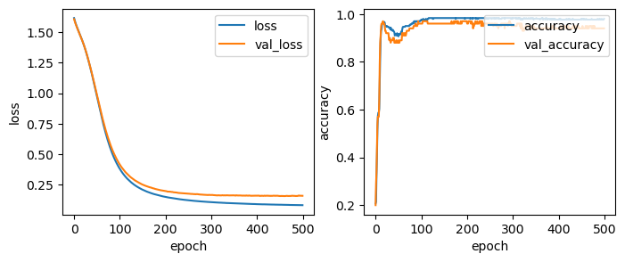

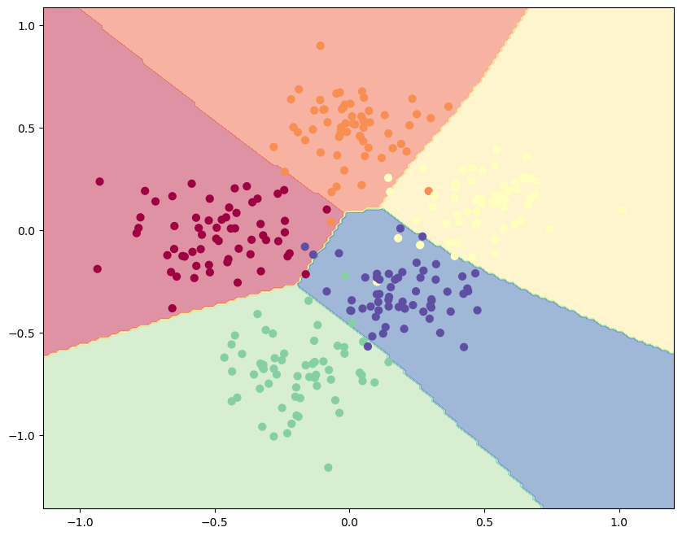

```python
from tensorflow.keras import Sequential
from tensorflow.keras.layers import Dense

blobs_neurnet = Sequential([
    Dense(64, activation='relu', input_shape=(2,)),  # First hidden layer
    Dense(64, activation='relu'),  # Second hidden layer
    Dense(5, activation='softmax')  # Output layer for 5 classes
])

history_blobs = train_neurnet(
    blobs_neurnet,
    X_blobs, y_blobs,
    X_blobs_val, y_blobs_val,
    n_epochs=500, batch_size=32
)

plot_classifier(X_blobs_test, y_blobs_test, blobs_neurnet)
```

```python
# Evaluate the model
test_loss, test_accuracy = blobs_neurnet.evaluate(X_blobs_test, y_blobs_test, verbose=0)
print(f"Blobs Test Loss: {test_loss:.4f}, Test Accuracy: {test_accuracy:.4f}")
```

```
Blobs Test Loss: 0.1398, Test Accuracy: 0.9500
```